# Analysis of Community Structure of the California Spiny Lobster

Pat Byrne

11/13/2019

### Data and Methods

This report uses data collected by researchers in the Santa Barbara Coastal Long Term Ecological Research program (see References for full citation). To obtain this data, divers counted and visually estimated the size of spiny lobsters present at five different kelp forest study sites in the Santa Barbara Channel during surveys conducted annually in the late summer. Of these sites, two (Naples and Isla Vista) are located within or near California Fish and Game Comission Marine Protected Areas (MPAs), whereas the other three (Arroyo Quemado, Carpenteria, and Mohawk) are not. The data itself was stored within ‘lobster_abundance_sbc_lter.csv’ and was in the form of counts of lobsters of a given size observed at a site in a year.

Dplyr::uncount() was used to spread the data into a more tidy format where each observation represented the time, place, and size metrics of an individual lobster. ggplot2::geom_line() was used to create a plot of lobster abundance through time at each site, and ggplot2::geom_density() was used to create a plot of kernel density estimates for the distribution of lobster size at each site in 2012 and 2018. Summary statistics of mean and standard deviation of lobster size at MPA and non-MPA sites in 2012 and 2018 were computed and displayed in a table using the kableExtra package. stats::t.test() was used to perform two-sided Welch’s t-tests at the 95% confidence level and assess the significance of the difference in mean lobster size between 2012 and 2018 and between MPA and non-MPA sites. Finally, effsize::cohen.d() was used to compute the value of Cohen’s d at the 95% confidence level and assess the effect size of the difference in mean lobster size between 2012 and 2018 and between MPA and non-MPA sites.

This analysis was performed in Rstudio version 1.2.1335 running R version 3.6.1. The following packages were used in this report:

- tidyverse, version 1.2.1
- janitor, version 1.2.0
- here, version 0.1
- effsize, version 0.7.6
- kableExtra, version 1.1.0
- scales, version 1.0.0

### Results

#### Lobster Abundance

In an effort to understand broad trends in the population of spiny lobsters across all the sites studied, counts of lobsters present at each site were plotted for the years 2012-2018 below in Figure 1.

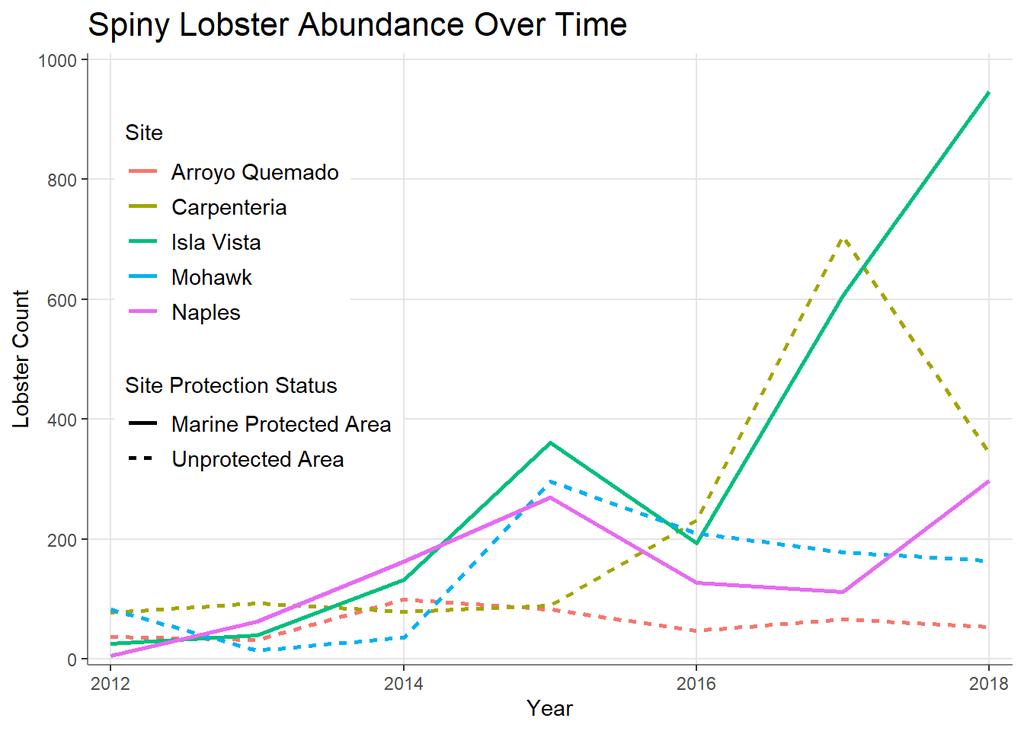

**Figure 1: Annual counts of Spiny Lobsters at five sites along the coast of the Santa Barbara Channel from the years 2012 through 2018.** *Lines indicate the number of lobsters observed by divers at a given site. Counts at the two sites designated as Marine Protected Areas are displayed as solid lines, whereas the three unprotected sites are dashed lines.*

Examining the timeseries shown in Figure 1, a few trends can be observed. Populations grew by varying amounts across sites. In 2012, all sites had relatively similar numbers of lobsters, all below 100. In 2018, the number counted ranged from 54 at Arroyo Quemado (which had little net change between 2012 and 2018) to 946 at Isla Vista. Importantly, MPA sites tended to grow more than non-MPA sites, having the largest and 3<sup>rd</sup>-largest (by a relatively narrow margin) numbers of lobsters present by 2018. This is consistent with the expectation that, as fishing activity decreases, the number of lobsters present will increase. Interestingly, the variations in population numbers were more consistent among MPA sites than non-MPA sites. This might be explained by cosistency of fishing practices. At the non-MPA sites, it is reasonable to expect that fishing practices might not be the same at each site, leading to different numbers of lobsters being taken and different population changes. However, at MPA sites the practices are the same (i.e. no fishing), leading to more similar population changes.

#### Lobster Size

Next, distributions of lobster sizes at each site were plotted in order to see how the size of lobsters present changed between 2012 and 2018, shown below in Figure 2.

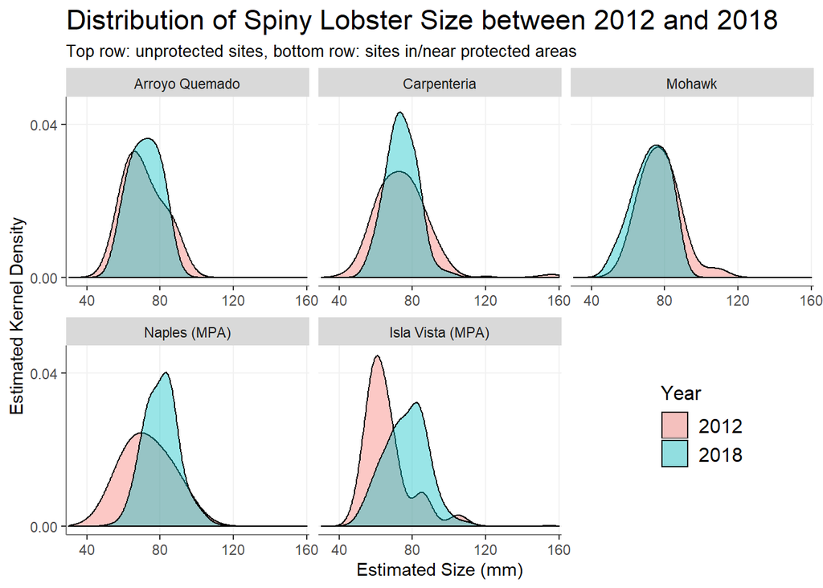

**Figure 2: Kernel density estimates of Spiny Lobster size at each site in the years 2012 and 2018.** *The two plots in the bottom row correspond to the MPA sites, whereas the plots in the top row correspond to the unprotected sites. Pink coloration corresponds to the year 2012, whereas blue corresponds to 2018.*

Examining the plots of estimated density, several key details are apparent. Most notably, distributions at both MPA sites showed shifts to the right, corresponding to an overall increase in lobster size. This is consistent with expectations. Without fishing pressures due to the MPA designations, lobsters at these sites would be more likely to live longer and grow larger, shifting the overall distribution of size upwards. Meanwhile, none of the non-MPA sights showed comparable shifts. Distributions for Arroyo Quemado and Carpenteria showed slight decreases in spread, and the distribution for Mohawk appeared to shift slightly to the left.

Figure 3: Summary statistics for samples of lobster sizes taken at MPA and non-MPA sites in the years 2012 and 2018.

| Sample Summary Statistics - Lobster Sizes Statistic | Sample Summary Statistics - Lobster Sizes MPA 2012 | Sample Summary Statistics - Lobster Sizes MPA 2018 | Sample Summary Statistics - Lobster Sizes Non-MPA 2012 | Sample Summary Statistics - Lobster Sizes Non-MPA 2018 |
| --- | --- | --- | --- | --- |
| Mean (mm) | 67.4 | 77.6 | 74.9 | 73.6 |
| Std. Deviation (mm) | 12.2 | 11.7 | 12.4 | 10.1 |
| Sample Size | 32.0 | 1244.0 | 199.0 | 561.0 |

Turning from a visual exploration to a more quantitative one, mean and standard deviations of lobster sizes at MPA and non-MPA sites were computed for 2012 and 2018. The values calculated can be found in Figure 3 to the right. A brief examination confirms that they are consistent with expectations based on Figure 2. Mean size increased for MPA sites but not for non-MPA sites, the standard deviation decreased for non-MPA sites, and the difference in sample sizes is consistent with the trends in overall abundance shown in Figure 1. Furthermore, examining the sample sizes confirms what Figure 1 suggests, that abundance of spiny lobsters increased more between 2012 and 2018 at MPA sites than it did at non-MPA sites.

Next, Welch’s t-tests were performed and Cohen’s d statistics were computed (both at the 95% confidence level) in order to more formally explore the differences in mean sizes between years and levels of protection. The results of these tests are shown below in Figure 4.

Figure 4: Results of t-tests and Cohen’s d calculations. t refers to the calculated t-statistic, and df refers to the degrees of freedom.

| Statistical Test Results - Lobster Sizes Test Type | Statistical Test Results - Lobster Sizes Difference in Means (mm) | Statistical Test Results - Lobster Sizes t | Statistical Test Results - Lobster Sizes df | Statistical Test Results - Lobster Sizes p-value | Statistical Test Results - Lobster Sizes Cohen’s D |
| --- | --- | --- | --- | --- | --- |
| MPA Sites: ’12 v. ’18 | -10.19 | -4.69 | 32.50 | 4.76e-05 | -0.87 |
| Non-MPA Sites: ’12 v. ’18 | 1.30 | 1.33 | 296.01 | 0.1831 | 0.12 |
| 2012: MPA v. Non-MPA | -7.55 | -3.25 | 42.09 | 2.26e-03 | -0.61 |
| 2018: MPA v. Non-MPA | 3.95 | 7.31 | 1239.51 | 4.88e-13 | 0.35 |

For MPA sites, we found a statistically significant difference in mean lobster sizes of -10.19*mm* between 2012 and 2018 (*t*(32.5) = -4.69, *p* = 4.76e-05, n = 32 for 2012 and 1244 for 2018). Given that the effect size was also large (Cohen’s *d* = -0.87), our results demonstrate that spiny lobster sizes at the sites studied increased by around 10*mm* in the six years following the designation of those sites as protected areas. Moreover, we found no such difference in mean sizes for non-MPA sites, only a non-significant difference of 1.3*mm* between 2012 and 2018(*t*(296.01) = 1.33, *p* = 0.1831, n = 199 for 2012 and 561 for 2018). These results are consistent with our expectations based on Figure 2 and the shifts in location (or lack thereof) of the distributions that it showed.

Moreover, our results also demonstrate a more subtle shift that Figure 2 did not clearly reveal. We found that in 2012, there was a statistically significant difference in mean lobster sizes of -7.55*mm* between MPA and non-MPA sites (*t*(42.09) = -3.25, *p* = 2.26e-03, n = 32 for MPA and 199 for non-MPA). That is, the lobsters studied were on average around 7.5*mm* bigger at non-MPA sites than MPA sites. Conversely, in 2018 there was a statistically significant difference in mean lobster sizes of 3.95*mm* between MPA and non-MPA sites (*t*(1239.51) = 7.31, *p* = 4.88e-13, n = 1244 for MPA and 561 for non-MPA). The lobsters studied were now on average around 4*mm* bigger at MPA sites than non-MPA sites.

### Summary

As shown in Figure 1 and the sample sizes in Figure 3, a greater increase in lobster abundance between 2012 and 2018 was observed at MPA sites than at non-MPA sites. Mean length of lobsters surveyed increased between 2012 and 2018 at MPA sites while the same increase was not observed at non-MPA sites (Figures 2 and 4). During that same time, mean length of lobsters surveyed went from being lower at MPA sites to lower at non-MPA sites (Figure 3). Taken together, these findings appear to demonstrate the positive impact that Marine Protected Area designations have had on the health of the California Spiny Lobster populations in the Santa Barbara channel.

### References

Reed D. 2019. SBC LTER: Reef: Abundance, size and fishing effort for California Spiny Lobster (Panulirus interruptus), ongoing since 2012. Environmental Data Initiative. https://doi.org/10.6073/pasta/a593a675d644fdefb736750b291579a0. Dataset accessed 11/13/2019.